# Problema 3 - Checkpoint 2

Julio Cesar Neves

31 de março de 2016

```r
#Dados disponíveis em http://statweb.stanford.edu/~tibs/ElemStatLearn/datasets/prostate.data
data <- read.table("prostate.data.txt", header=T, sep="\t")
train <- data[data$train == T, ]
test <-data[data$train == F, ]
```

# Descrição do Problema

O PSA, Antígeno Prostático Específico, é uma substância produzida pelas células da glândula prostática. O principal local onde o PSA pode ser encontrado é o sêmen, mas uma pequena quantidade também pode ser encontrada no sangue.  
Níveis de PSA acima de 4ng/ml indicam um possível comprometimento da glândula prostática e quanto maior a quantidade do antígeno presente no sangue, maior a probabilidade do paciente apresentar câncer de próstata. Por causa disso, a medição do nível do PSA é utilizada como uns dos principais meios de diagnosticar o câncer de próstata.

# Objetivo

# Visualizando os dados

Antes de prosseguir com a análise de regressão, vamos obter mais informações sobre as variáveis disponíveis. Primeiramente, vamos verificar se há entradas incompletas em nossos dados.

```r
sum(!complete.cases(train))
```

```
## [1] 0
```

É possível verificar que aparentemente todos os nossos dados estão completos. Em seguida, podemos fazer a exploração das variáveis, verificando a distribuição das mesmas e a possível presença de padrões.

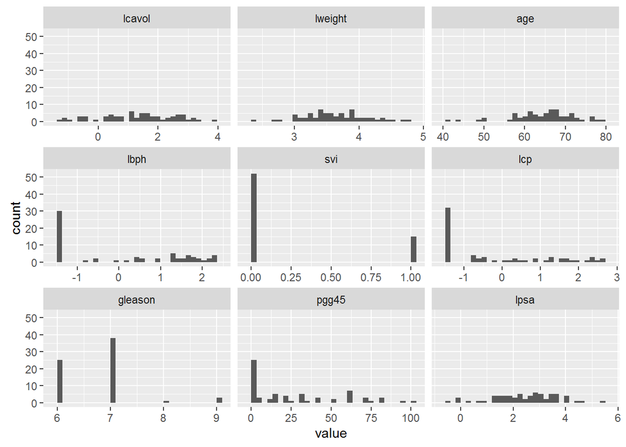

```r
library(ggplot2)
library(reshape)
cols <- ncol(train)
d <- melt(train[,-c(1, cols)])
ggplot(d ,aes(x = value)) +
  facet_wrap(~variable, scales = "free_x") +
  geom_histogram()
```

A partir do gráfico das variáveis podemos observar que as variáveis que representam o volume do câncer (lcavol), o peso do paciente (lweight), o nível de hiperplasia (lbph) e o nível de penetração capsular (lcp) parecem estar em escala logaritmica.  
Nas variáveis lbph e lcp, conseguimos perceber que há um valor que concentra muitas ocorrências, a saber -1.3862944. Não foi possível explicar tal concentração com os dados disponíveis. Além disso, tudo indica que a variável svi indique um valor lógico binário por meio dos números 0 e 1.

# Escolha de preditores

Para escolher que preditores utilizaremos em nossa análise, podemos começar excluindo os preditores de variância muito próxima a zero, pois estes podem gerar confusão em nosso modelo de regressão. Após isso, podemos testar quais deles estão correlacionados, a fim de evitar redundâncias.

## Análise de Variância

O total de variáveis preditoras com variância próxima a zero pode ser descoberta utilizando a biblioteca caret da linguagem R:

```r
library("caret")
print(nearZeroVar(train[,3:ncol(train)-1], saveMetrics = FALSE))
```

```
## integer(0)
```

Como podemos observar, não há variáveis com variância próxima ou igual a zero em nossos dados.

## Verificação de Correlação

O próximo passo é verificar quais variáveis preditoras estão correlacionadas. Assim saberemos quais variáveis podem ser retiradas de nosso modelo sem prejuízos a acurácia do modelo. Para verificar a correlação entre as variáveis, vamos utilizar um gráfico baseado na matriz de correlação.

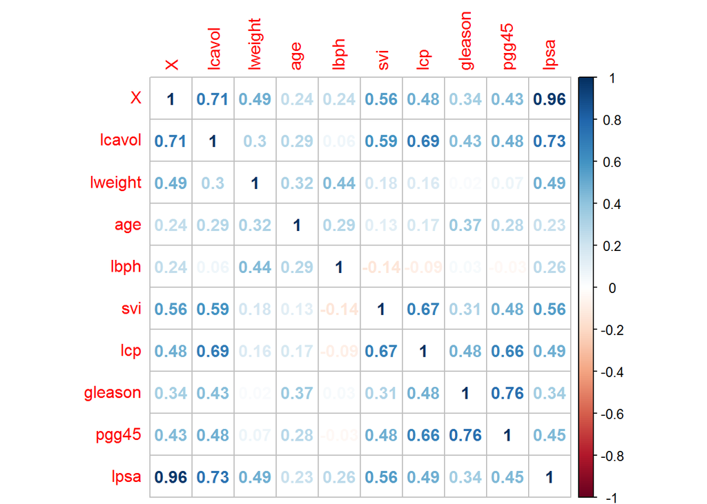

```r
library("corrplot")
nums <- sapply(train, is.numeric)
correlations = cor(train[,nums], method="pearson")
corrplot(correlations, method="number")
```

O gráfico nos mostra que nossa variável resposta (lpsa) apresenta um nível de correlação considerável com as variáveis lcavol, svi, lcp e lweight. O que nos indica que há uma grande possibilidade dessas variáveis fazerem parte do modelo que buscamos. Restringindo nossa análise de correlação a estas variáveis, podemos ver que lcavol apresenta um nível de correlação considerável com lcp e svi, que por sua vez, também estão correlacionadas. Isso significa que podemos tentar modelar nosso problema usando apenas uma dessas variáveis e verificar se obtemos um bom resultado.

# Proposição de modelos

O primeiro modelo proposto usa apenas a variável com maior correlação com a variável de resposta, a saber, lcavol. A tabela de sumarização e o gráfico da regressão para os dados de treino pode ser vistos abaixo.

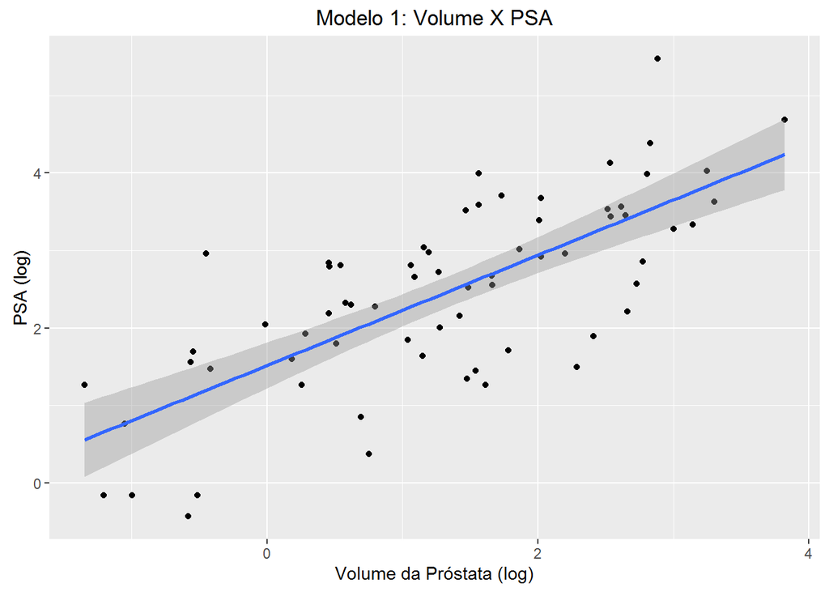

```r
ggplot(train, aes(lcavol, lpsa)) +
        geom_point() +
        geom_smooth(method = "lm") +
        labs(x="Volume da Próstata (log)",y="PSA (log)",title="Modelo 1: Volume X PSA")
```

```r
model1 <- lm(lpsa ~ lcavol, train)
summary(model1)
```

```
##
## Call:
## lm(formula = lpsa ~ lcavol, data = train)
##
## Residuals:
##     Min      1Q  Median      3Q     Max
## -1.6802 -0.4240  0.1684  0.5392  1.9070
##
## Coefficients:
##             Estimate Std. Error t value Pr(>|t|)
## (Intercept)  1.51630    0.14772  10.264 3.12e-15 ***
## lcavol       0.71264    0.08199   8.692 1.73e-12 ***
## ---
## Signif. codes:  0 '***' 0.001 '**' 0.01 '*' 0.05 '.' 0.1 ' ' 1
##
## Residual standard error: 0.8277 on 65 degrees of freedom
## Multiple R-squared:  0.5375, Adjusted R-squared:  0.5304
## F-statistic: 75.55 on 1 and 65 DF,  p-value: 1.733e-12
```

```r
model2 <- lm(lpsa ~ lcavol + lweight, train)
summary(model2)
```

```
##
## Call:
## lm(formula = lpsa ~ lcavol + lweight, data = train)
##
## Residuals:
##      Min       1Q   Median       3Q      Max
## -1.58852 -0.44174  0.01304  0.52613  1.93127
##
## Coefficients:
##             Estimate Std. Error t value Pr(>|t|)
## (Intercept) -1.04944    0.72904  -1.439 0.154885
## lcavol       0.62761    0.07906   7.938 4.14e-11 ***
## lweight      0.73838    0.20613   3.582 0.000658 ***
## ---
## Signif. codes:  0 '***' 0.001 '**' 0.01 '*' 0.05 '.' 0.1 ' ' 1
##
## Residual standard error: 0.7613 on 64 degrees of freedom
## Multiple R-squared:  0.6148, Adjusted R-squared:  0.6027
## F-statistic: 51.06 on 2 and 64 DF,  p-value: 5.54e-14
```

Em nosso novo modelo, obtemos RMSE de 0.7613, R^2 ajustado de aproximademente 0.603 e um p-valor ainda menor que o encontrado anteriormente: $5.54*10^{-14}$ A diferença entre os RMSE’s e R^2 ajustados de nossos modelos 1 e 2 parece pequena, mas já pode ser considerada significativa e podemos concluir que nosso modelo 2 é melhor que o modelo 1.

Após nosso modelo 2, outros modelos poderiam ser propostos. Além das variáveis utilizadas no modelo 2, estes contariam com outras variáveis com correlação significativa em relação a lpsa (pgg45 e svi), mas eles foram testados e nenhum deles aumentou muito a acurácia do modelo. Por apresentarem complexidade grande para pouco ganho, foram descartados.

# Testando nosso modelo

Após achar nosso suposto modelo ideal, precisamos testá-lo. Para isso, usaremos os dados de teste disponibilizados no dataset utilizado nesse problema. Abaixo podemos ver a tabela de sumarização obtida a partir do modelo 2 e de nossos dados de teste.

```r
model2 <- lm(lpsa ~ lcavol + lweight, test)
summary(model2)
```

```
##
## Call:
## lm(formula = lpsa ~ lcavol + lweight, data = test)
##
## Residuals:
##      Min       1Q   Median       3Q      Max
## -1.29207 -0.49256 -0.05637  0.35382  1.61070
##
## Coefficients:
##             Estimate Std. Error t value Pr(>|t|)
## (Intercept)   0.4078     1.6355   0.249    0.805
## lcavol        0.7235     0.1324   5.464 8.77e-06 ***
## lweight       0.3007     0.4561   0.659    0.515
## ---
## Signif. codes:  0 '***' 0.001 '**' 0.01 '*' 0.05 '.' 0.1 ' ' 1
##
## Residual standard error: 0.7237 on 27 degrees of freedom
## Multiple R-squared:  0.551,  Adjusted R-squared:  0.5177
## F-statistic: 16.57 on 2 and 27 DF,  p-value: 2.021e-05
```